# Penguins Database - Clusters

Diplomado de métodos matemáticos y estadísticos para la Ciencia de Datos

Equipo 7 Integrantes: Fajardo Zavala Yendali Viridiana González Rivas José Rafael Maldonado Zamora Silvia Viridiana Olivera Flores Jonathan Valencia Quiroz Luis Roberto

2026-01-16

# Descripción

El dataset penguins.csv contiene mediciones biométricas de pingüinos recolectadas en las Islas Palmer (Antártida). Contiene 344 registros y 8 variables. El objetivo de este trabajo es explorar, describir y reducir la dimensionalidad de las variables numéricas para identificar patrones y relaciones entre individuos, y evaluar si estas mediciones permiten distinguir especies mediante técnicas como PCA, t-SNE y UMAP.

# Variables

El dataset incluye variables categóricas, por ejemplo:

1. species: Categórica. La especie del pingüino (Adelie, Chinstrap o Gentoo).
2. island: Categórica. La isla de observación (Torgersen, Biscoe o Dream).

Además, incluye variables numéricas relacionadas con rasgos físicos, como:

3. bill_length_mm: Numérica (float). Longitud del pico en milímetros.
4. bill_depth_mm: Numérica (float). Profundidad del pico en milímetros.
5. flipper_length_mm: Numérica (float). Longitud de la aleta en milímetros.
6. body_mass_g: Numérica (float). Masa corporal en gramos.
7. sex: Categórica. El sexo del pingüino (male o female).
8. year: Numérica (integer). El año de la observación.

Estas variables permiten comparar individuos, analizar distribuciones y explorar qué mediciones aportan más información para separar especies

# Explorando el dataset

Dimensión del conjunto de datos

| Métrica | Valor |
| --- | --- |
| Número de observaciones | 344 |
| Número de variables | 8 |

Primeras filas del conjunto de datos

| species | island | bill_length_mm | bill_depth_mm | flipper_length_mm | body_mass_g | sex | year |
| --- | --- | --- | --- | --- | --- | --- | --- |
| Adelie | Torgersen | 39.1 | 18.7 | 181 | 3750 | male | 2007 |
| Adelie | Torgersen | 39.5 | 17.4 | 186 | 3800 | female | 2007 |
| Adelie | Torgersen | 40.3 | 18.0 | 195 | 3250 | female | 2007 |
| Adelie | Torgersen | NA | NA | NA | NA | NA | 2007 |
| Adelie | Torgersen | 36.7 | 19.3 | 193 | 3450 | female | 2007 |
| Adelie | Torgersen | 39.3 | 20.6 | 190 | 3650 | male | 2007 |

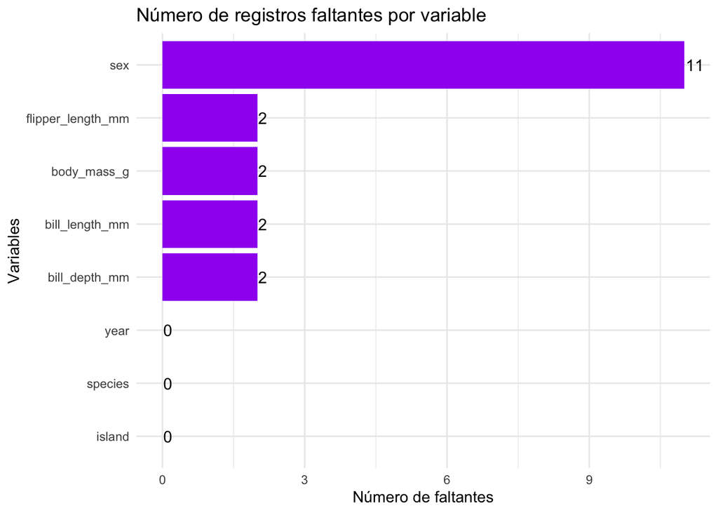

```
## No se identificaron registros duplicados en el conjunto de datos.
```

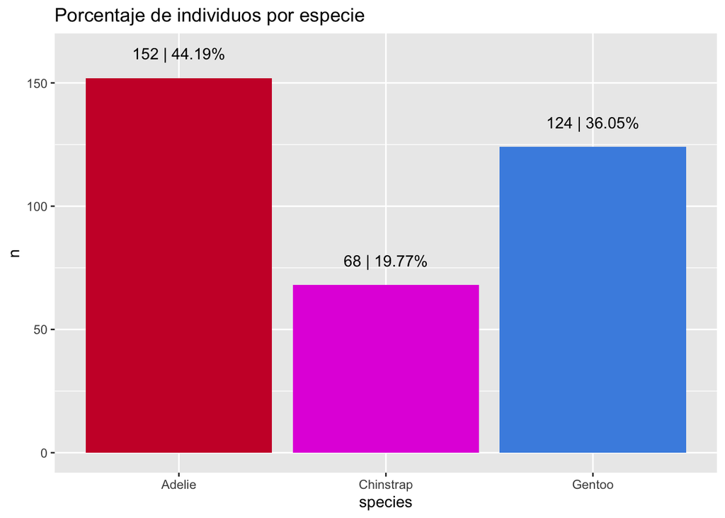

```markdown
Se transforma species a factor para usarla como variable de clasificación/etiqueta en las gráficas comparativas.
```

```r
# Preparación de los datos para clustering

df1 <- df %>%
  select(where(is.numeric)) %>%
  select(-year) %>%
  drop_na() %>%
  scale() %>%
  as.data.frame()

summary(df1)
```

```
##  bill_length_mm     bill_depth_mm      flipper_length_mm  body_mass_g
##  Min.   :-2.16535   Min.   :-2.05144   Min.   :-2.0563   Min.   :-1.8726
##  1st Qu.:-0.86031   1st Qu.:-0.78548   1st Qu.:-0.7762   1st Qu.:-0.8127
##  Median : 0.09672   Median : 0.07537   Median :-0.2784   Median :-0.1892
##  Mean   : 0.00000   Mean   : 0.00000   Mean   : 0.0000   Mean   : 0.0000
##  3rd Qu.: 0.83854   3rd Qu.: 0.78430   3rd Qu.: 0.8594   3rd Qu.: 0.6836
##  Max.   : 2.87166   Max.   : 2.20217   Max.   : 2.1395   Max.   : 2.6164
```

```r
head(df1)
```

|  | bill_length_mm | bill_depth_mm | flipper_length_mm | body_mass_g |
| --- | --- | --- | --- | --- |
| 1 | -0.8832047 | 0.7843001 | -1.4162715 | -0.5633167 |
| 2 | -0.8099390 | 0.1260033 | -1.0606961 | -0.5009690 |
| 3 | -0.6634077 | 0.4298326 | -0.4206603 | -1.1867934 |
| 4 | -1.3227986 | 1.0881294 | -0.5628905 | -0.9374027 |
| 5 | -0.8465718 | 1.7464261 | -0.7762357 | -0.6880121 |
| 6 | -0.9198375 | 0.3285561 | -1.4162715 | -0.7191859 |

```r
# Calculando distancias (distancia euclideana)

dist_df <- dist(df1, method = "euclidean")

hc_ave    <- hclust(dist_df, method = "average")
hc_single <- hclust(dist_df, method = "single")
hc_comp   <- hclust(dist_df, method = "complete")
hc_ward   <- hclust(dist_df, method = "ward.D")
hc_ward2  <- hclust(dist_df, method = "ward.D2")

###Distancia cophenetic

d_ave    <- cophenetic(hc_ave)
d_single <- cophenetic(hc_single)
d_comp   <- cophenetic(hc_comp)
d_ward   <- cophenetic(hc_ward)
d_ward2  <- cophenetic(hc_ward2)

cbind(
  average  = cor(dist_df, d_ave),
  single   = cor(dist_df, d_single),
  complete = cor(dist_df, d_comp),
  ward     = cor(dist_df, d_ward),
  ward2    = cor(dist_df, d_ward2)
)
```

```
##        average    single  complete      ward     ward2
## [1,] 0.8447094 0.8131742 0.8281833 0.8188395 0.8346438
```

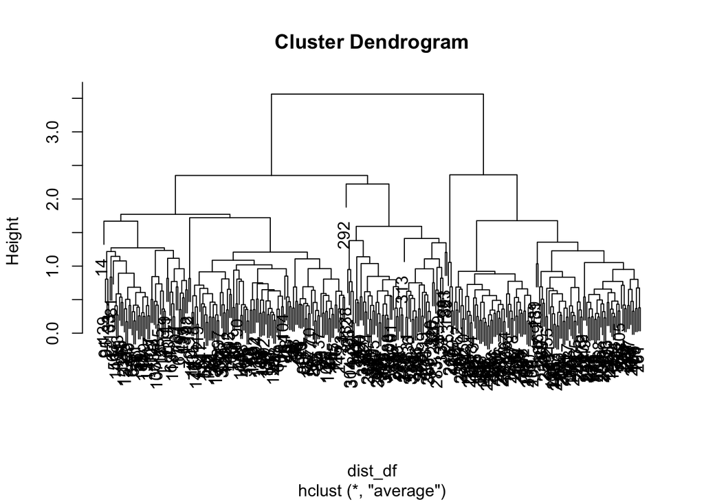

```r
# Dendrogramas

plot(hc_ave)
```

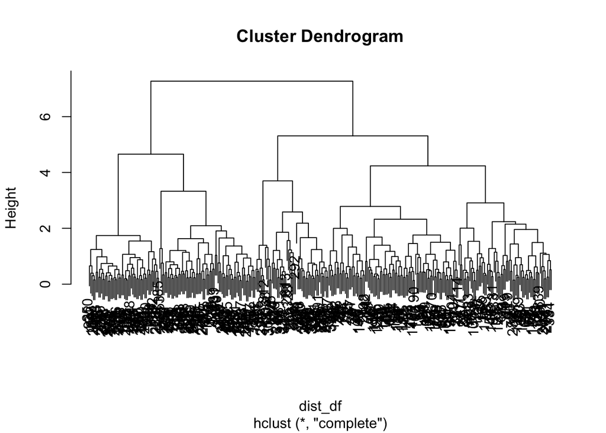

```r
plot(hc_comp)
```

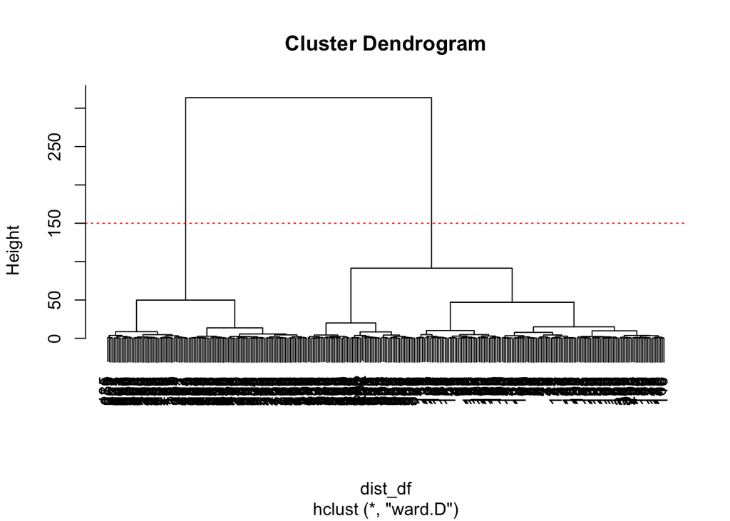

```r
plot(hc_ward)
abline(h = 150, lty = 3, col = "red")
```

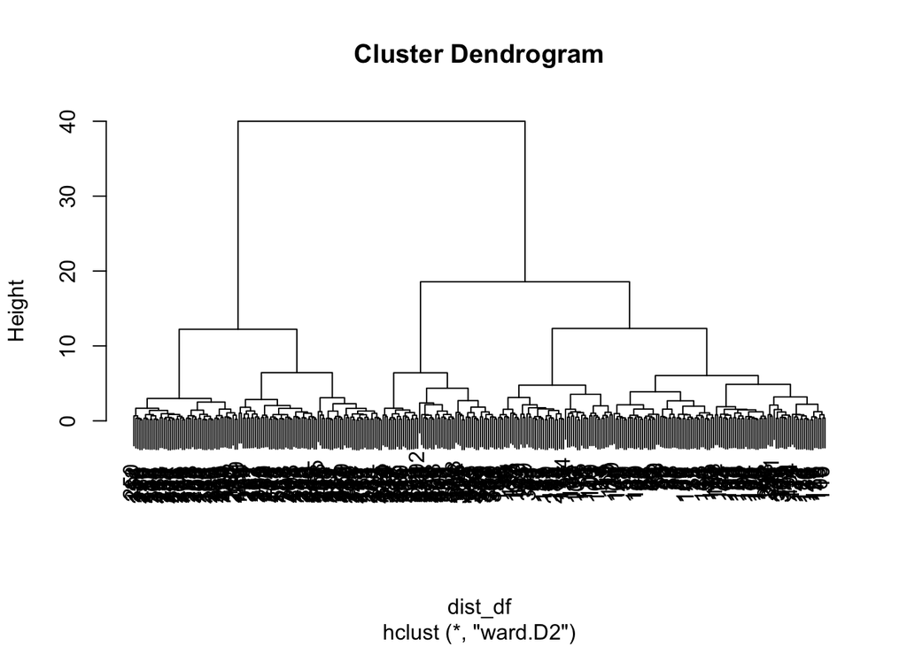

```r
plot(hc_ward2)
abline(h = 45, lty = 3, col = "red")
```